# Assignment 15: Writing a function - Conditional Statement

*How to do it?*:

- Open the Rmarkdown file of this assignment (link) in Rstudio.
- Right under each **question**, insert a code chunk (you can use the hotkey `Ctrl + Alt + I` to add a code chunk) and code the solution for the question.
- `Knit` the rmarkdown file (hotkey: `Ctrl + Alt + K`) to export an html.
- Publish the html file to your Githiub Page.

*Submission*: Submit the link on Github of the assignment to Canvas

#### NOTICE: Question 7 and 8 are optional.

1. Write a function to calculate the age of a person. Give an example to test your function.
- Input: a number, x, (year born)
- Output: Print out “You are r age”. Where r is the age of the person, i.e. 2020 - x.

```r
age <- function(x){
  r=2021-x
  print(paste0('You are ',r,' years old'))
}
age(2001)
```

```
## [1] "You are 20 years old"
```

Hint: [Similar Function](https://bryantstats.github.io/math421/gganimate/17_writing_functions_fa21.html#41)

2. Write the following function. Give an example to test your function.
- Input: a number
- Output: print out: “You input an even number!” if the number is event, or “You input an odd number!” otherwise.

```r
number <- function(x)
{
  if (x%%2==0) {print('You input an even number.')} else {print('You input an odd number.')}
}
number(5)
```

```
## [1] "You input an odd number."
```

Hint: [Similar Function](https://bryantstats.github.io/math421/gganimate/17_writing_functions_fa21.html#45)

3. Write the following function. Give an example to test your function.
- Input: a numeric vector
- Output:
  - if the input vector has missing values: return the input vector with missing values replaced by mean
  - if the input vector has no missing value: return the same input vector

```r
impute <- function(x)
{
  if(is.numeric(x))
  { meanx <- mean(x, na.rm=TRUE)
  library(tidyr)
  x <- replace_na(x,meanx)}
  return(x)
}
library(tidyverse)
a <- read_csv('titanic.csv')
impute(a$Age)
```

```
##   [1] 22.00000 38.00000 26.00000 35.00000 35.00000 29.69912 54.00000  2.00000
##   [9] 27.00000 14.00000  4.00000 58.00000 20.00000 39.00000 14.00000 55.00000
##  [17]  2.00000 29.69912 31.00000 29.69912 35.00000 34.00000 15.00000 28.00000
##  [25]  8.00000 38.00000 29.69912 19.00000 29.69912 29.69912 40.00000 29.69912
##  [33] 29.69912 66.00000 28.00000 42.00000 29.69912 21.00000 18.00000 14.00000
##  [41] 40.00000 27.00000 29.69912  3.00000 19.00000 29.69912 29.69912 29.69912
##  [49] 29.69912 18.00000  7.00000 21.00000 49.00000 29.00000 65.00000 29.69912
##  [57] 21.00000 28.50000  5.00000 11.00000 22.00000 38.00000 45.00000  4.00000
##  [65] 29.69912 29.69912 29.00000 19.00000 17.00000 26.00000 32.00000 16.00000
##  [73] 21.00000 26.00000 32.00000 25.00000 29.69912 29.69912  0.83000 30.00000
##  [81] 22.00000 29.00000 29.69912 28.00000 17.00000 33.00000 16.00000 29.69912
##  [89] 23.00000 24.00000 29.00000 20.00000 46.00000 26.00000 59.00000 29.69912
##  [97] 71.00000 23.00000 34.00000 34.00000 28.00000 29.69912 21.00000 33.00000
## [105] 37.00000 28.00000 21.00000 29.69912 38.00000 29.69912 47.00000 14.50000
## [113] 22.00000 20.00000 17.00000 21.00000 70.50000 29.00000 24.00000  2.00000
```

[output cut: 97 more lines]

```r
mean(a$Age, na.rm=TRUE)
```

```
## [1] 29.69912
```

Hint: [Similar Function](https://bryantstats.github.io/math421/gganimate/17_writing_functions_fa21.html#49)

4. Write the following function. Give an example to test your function.
- Input: a vector x
- Output: The vector x where the missing values replaced by the mean (if x is numeric) or the mode (if x is non-numeric). If x does not have missing value, return the same vector x.

```r
imputeboth <- function(x)
{
  if(is.numeric(x))
  { meanx <- mean(x, na.rm=TRUE)
  library(tidyr)
  x <- replace_na(x,meanx)} else {modex <-  names(sort(-table(x)))[1]
  x <- replace_na(x,modex)}
  return(x)
}
imputeboth(a$Embarked)
```

```
##   [1] "S" "C" "S" "S" "S" "Q" "S" "S" "S" "C" "S" "S" "S" "S" "S" "S" "Q" "S"
##  [19] "S" "C" "S" "S" "Q" "S" "S" "S" "C" "S" "Q" "S" "C" "C" "Q" "S" "C" "S"
##  [37] "C" "S" "S" "C" "S" "S" "C" "C" "Q" "S" "Q" "Q" "C" "S" "S" "S" "C" "S"
##  [55] "C" "S" "S" "C" "S" "S" "C" "S" "S" "S" "C" "C" "S" "S" "S" "S" "S" "S"
##  [73] "S" "C" "S" "S" "S" "S" "S" "S" "S" "S" "Q" "S" "S" "S" "S" "S" "S" "S"
##  [91] "S" "S" "S" "S" "S" "S" "C" "C" "S" "S" "S" "S" "S" "S" "S" "S" "S" "S"
## [109] "S" "Q" "S" "C" "S" "S" "C" "S" "Q" "S" "C" "S" "S" "S" "C" "S" "S" "C"
## [127] "Q" "S" "C" "S" "C" "S" "S" "S" "S" "C" "S" "S" "S" "C" "C" "S" "S" "Q"
## [145] "S" "S" "S" "S" "S" "S" "S" "S" "S" "S" "S" "C" "Q" "S" "S" "S" "S" "S"
## [163] "S" "S" "S" "S" "S" "S" "S" "S" "S" "Q" "S" "S" "C" "S" "S" "C" "S" "S"
## [181] "S" "C" "S" "S" "S" "S" "Q" "S" "Q" "S" "S" "S" "S" "S" "C" "C" "Q" "S"
## [199] "Q" "S" "S" "S" "S" "C" "S" "S" "S" "C" "Q" "C" "S" "S" "S" "S" "Q" "C"
## [217] "S" "S" "C" "S" "S" "S" "S" "S" "S" "S" "S" "S" "S" "S" "S" "S" "S" "S"
## [235] "S" "S" "S" "S" "S" "S" "C" "Q" "S" "S" "C" "Q" "S" "S" "S" "S" "S" "S"
## [253] "S" "S" "S" "C" "C" "S" "C" "S" "Q" "S" "S" "S" "Q" "S" "S" "S" "S" "S"
```

[output cut: 35 more lines]

```r
imputeboth(a$Age)
```

```
##   [1] 22.00000 38.00000 26.00000 35.00000 35.00000 29.69912 54.00000  2.00000
##   [9] 27.00000 14.00000  4.00000 58.00000 20.00000 39.00000 14.00000 55.00000
##  [17]  2.00000 29.69912 31.00000 29.69912 35.00000 34.00000 15.00000 28.00000
##  [25]  8.00000 38.00000 29.69912 19.00000 29.69912 29.69912 40.00000 29.69912
##  [33] 29.69912 66.00000 28.00000 42.00000 29.69912 21.00000 18.00000 14.00000
##  [41] 40.00000 27.00000 29.69912  3.00000 19.00000 29.69912 29.69912 29.69912
##  [49] 29.69912 18.00000  7.00000 21.00000 49.00000 29.00000 65.00000 29.69912
##  [57] 21.00000 28.50000  5.00000 11.00000 22.00000 38.00000 45.00000  4.00000
##  [65] 29.69912 29.69912 29.00000 19.00000 17.00000 26.00000 32.00000 16.00000
##  [73] 21.00000 26.00000 32.00000 25.00000 29.69912 29.69912  0.83000 30.00000
##  [81] 22.00000 29.00000 29.69912 28.00000 17.00000 33.00000 16.00000 29.69912
##  [89] 23.00000 24.00000 29.00000 20.00000 46.00000 26.00000 59.00000 29.69912
##  [97] 71.00000 23.00000 34.00000 34.00000 28.00000 29.69912 21.00000 33.00000
## [105] 37.00000 28.00000 21.00000 29.69912 38.00000 29.69912 47.00000 14.50000
## [113] 22.00000 20.00000 17.00000 21.00000 70.50000 29.00000 24.00000  2.00000
```

[output cut: 97 more lines]

Hint: Use If-statement to combine the function in Question 3 and [this function](https://bryantstats.github.io/math421/gganimate/17_writing_functions_fa21.html#49)

5. Write the following function. Give examples to test your function.
- Input: A data frame of two variables x and y
- Output:
  - A boxplot of x by y if x is numeric and y is non-numeric
  - A boxplot of y by x if y is numeric and x is non-numeric
  - print out ‘This function cannot visualize your data’ otherwise

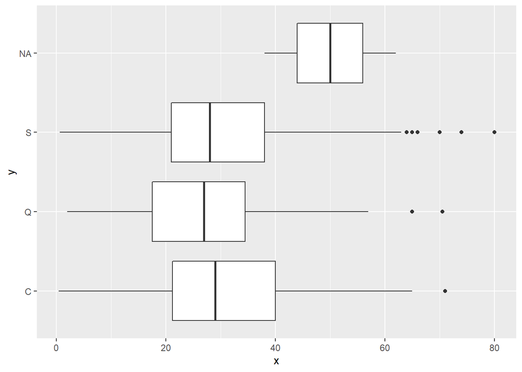

```r
viz <- function(x,y)
{
  if(is.numeric(x)&(!(is.numeric(y))))
  {
  ggplot()+
  geom_boxplot(mapping = aes(x = x, y = y))
  }
  else if (is.numeric(y)&(!(is.numeric(x))))
  {
     ggplot()+
  geom_boxplot(mapping = aes(x = y, y = x))
  }
  else
  {
    print('This function cannot visualize your data.')
  }
}
viz(a$Age,a$Embarked)
```

Hint:

- [Similar Function](https://bryantstats.github.io/math421/gganimate/17_writing_functions_fa21.html#53)
- You can refer to this slide to plot a boxplot: https://bryantstats.github.io/math421/slides/6_viz.html#36
6. Combine the function in Question 5 and the function in this example ([Link](https://bryantstats.github.io/math421/gganimate/17_writing_functions_fa21.html#53)) to have a function that can plot all possible cases (2 categorical, 2 numeric, 1 numeric and 1 categorical).

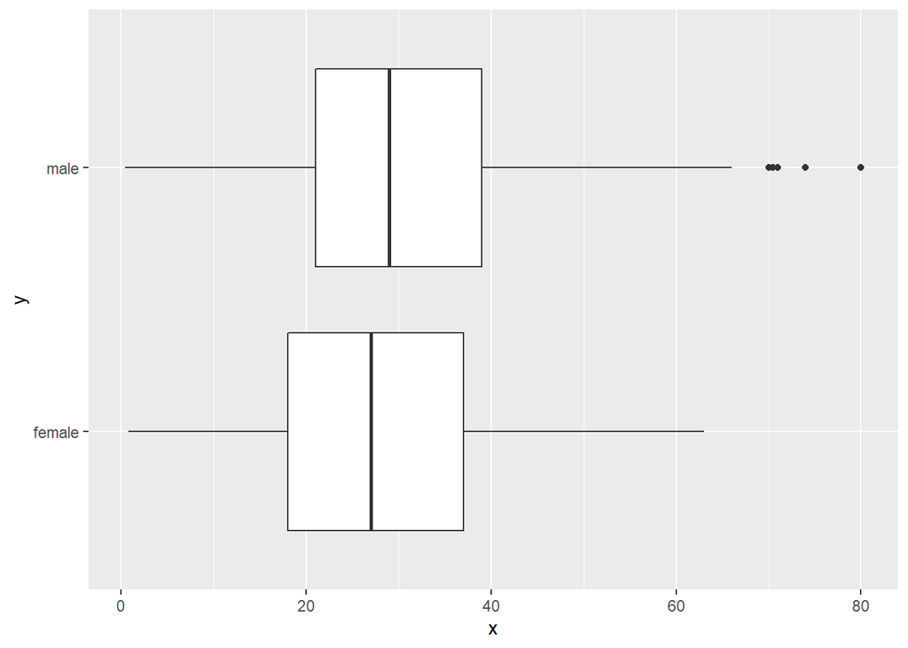

```r
viz1 <- function(x,y)
{
  if(is.numeric(x)&(!(is.numeric(y))))
  {
  ggplot()+
  geom_boxplot(mapping = aes(x = x, y = y))
  }
  else if (is.numeric(y)&(!(is.numeric(x))))
  {
     ggplot()+
  geom_boxplot(mapping = aes(x = y, y = x))
  }
   else if (!(is.numeric(y))&(!(is.numeric(x))))
  {
     ggplot(aes(x = x, fill = y))+
      geom_bar(position = 'dodge')+
      labs(x = x, fill = y)
   }
  else if (is.numeric(y)&(is.numeric(x)))
  {
     ggplot(aes(x = x, y = y))+
      geom_point()+
      labs(x = x, y =y)
  }
  else
  {
    print('This function cannot visualize your data.')
  }
}
viz1(a$Age,a$Sex)
```

#### NOTICE: Question 7 and 8 are optional.

Sample codes

- [Word Cloud codes](https://bryantstats.github.io/math421/text_mining_sample_codes2.html#2_Word_Cloud)
- [A similar function](https://bryantstats.github.io/math421/gganimate/17_writing_functions_fa21_fa21.html#10)